# SR_02_RLTD_ORG_ADDR_STATE

Related organization state · Code report

## Overview

**Description**

Province or state

**Table**

`SR-P02-T01-ID-RLTD-TAX-EXEMPED-ORGS` (many)

**Location code**

`SCHED-R-PART-02-COL-A`

**Family**

`SCHED-R-PART-02-COL-A` · siblings: SR_02_RLTD_ORG_ADDR_CITY, SR_02_RLTD_ORG_ADDR_CNTR, SR_02_RLTD_ORG_ADDR_L1, SR_02_RLTD_ORG_ADDR_L2, SR_02_RLTD_ORG_ADDR_ZIP, SR_02_RLTD_ORG_EIN

**Data type**

text (xsd: TextType, StateType)

**Scope**

PC

**Status**

unreviewed

6

xpaths mapped (6 observed)

838,563

filings with a value

2009–2024

tax years observed

3

open flags (1 errors)

## Flags

| Severity | Flag | Xpath | Detail |
| --- | --- | --- | --- |
| ⚠ error | `COLLISION` | IRS990ScheduleR/IdRelatedTaxExemptOrgGrp/ForeignAddress/ProvinceOrStateNm | 3749 filings contain 2+ of its xpaths; most common set: /Return/ReturnData/IRS990ScheduleR/IdRelatedTaxExemptOrgGrp/ForeignAddress/ProvinceOrStateNm ; /Return/ReturnData/IRS990ScheduleR/IdRelatedTaxEx… |
| ⓘ info | `MANY_NOT_REPEATING` | IRS990ScheduleR/IdRelatedTaxExemptOrgGrp/USAddress/StateAbbreviationCd | many-to-one table, but 52% of values sit in no repeating element |
| ⓘ info | `MANY_NOT_REPEATING` | IRS990ScheduleR/IdRelatedTaxExemptOrgGrp/USAddress/State | many-to-one table, but 50% of values sit in no repeating element |

## Xpaths

All mapped xpaths (under /Return/ReturnData or /Return/ReturnHeader), oldest first. Charts label each series by its xpath.

| Xpath | Form | Chart label | First year | Last year | Versions | Filings | Repeats in |
| --- | --- | --- | --- | --- | --- | --- | --- |
| IRS990ScheduleR/Form990ScheduleRPartII/AddressUS/State | Sched R | same | 2009 | 2012 | 18 | 132,312 | 51.3% |
| IRS990ScheduleR/Form990ScheduleRPartII/AddressForeign/ProvinceOrState | Sched R | …leR/Form990ScheduleRPartII/AddressForeign/ProvinceOrState | 2009 | 2012 | 14 | 717 | 29.3% |
| IRS990ScheduleR/IdRelatedTaxExemptOrgGrp/USAddress/State | Sched R | same | 2013 | 2013 | 3 | 47,596 | 49.2% |
| IRS990ScheduleR/IdRelatedTaxExemptOrgGrp/ForeignAddress/ProvinceOrState | Sched R | …R/IdRelatedTaxExemptOrgGrp/ForeignAddress/ProvinceOrState | 2013 | 2013 | 3 | 293 | 28.3% |
| IRS990ScheduleR/IdRelatedTaxExemptOrgGrp/USAddress/StateAbbreviationCd | Sched R | …eR/IdRelatedTaxExemptOrgGrp/USAddress/StateAbbreviationCd | 2014 | 2024 | 34 | 651,290 | 47.9% |
| IRS990ScheduleR/IdRelatedTaxExemptOrgGrp/ForeignAddress/ProvinceOrStateNm | Sched R | …IdRelatedTaxExemptOrgGrp/ForeignAddress/ProvinceOrStateNm | 2014 | 2024 | 34 | 6,355 | 23.1% |

## Coverage

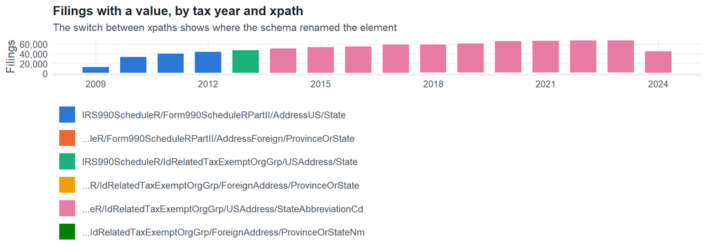

**Table view**

Table view: filings by tax year and series

| Tax year | IRS990ScheduleR/Form990ScheduleRPartII/AddressUS/State | …leR/Form990ScheduleRPartII/AddressForeign/ProvinceOrState | IRS990ScheduleR/IdRelatedTaxExemptOrgGrp/USAddress/State | …R/IdRelatedTaxExemptOrgGrp/ForeignAddress/ProvinceOrState | …eR/IdRelatedTaxExemptOrgGrp/USAddress/StateAbbreviationCd | …IdRelatedTaxExemptOrgGrp/ForeignAddress/ProvinceOrStateNm |
| --- | --- | --- | --- | --- | --- | --- |
| 2009 | 13,294 | 80 | 0 | 0 | 0 | 0 |
| 2010 | 33,609 | 166 | 0 | 0 | 0 | 0 |
| 2011 | 40,919 | 219 | 0 | 0 | 0 | 0 |
| 2012 | 44,490 | 252 | 0 | 0 | 0 | 0 |
| 2013 | 0 | 0 | 47,596 | 293 | 0 | 0 |
| 2014 | 0 | 0 | 0 | 0 | 51,116 | 334 |
| 2015 | 0 | 0 | 0 | 0 | 53,523 | 427 |
| 2016 | 0 | 0 | 0 | 0 | 55,448 | 446 |
| 2017 | 0 | 0 | 0 | 0 | 58,874 | 506 |
| 2018 | 0 | 0 | 0 | 0 | 59,172 | 555 |
| 2019 | 0 | 0 | 0 | 0 | 60,848 | 632 |
| 2020 | 0 | 0 | 0 | 0 | 65,651 | 698 |
| 2021 | 0 | 0 | 0 | 0 | 66,652 | 732 |
| 2022 | 0 | 0 | 0 | 0 | 67,472 | 776 |
| 2023 | 0 | 0 | 0 | 0 | 67,375 | 790 |
| 2024 | 0 | 0 | 0 | 0 | 45,159 | 459 |

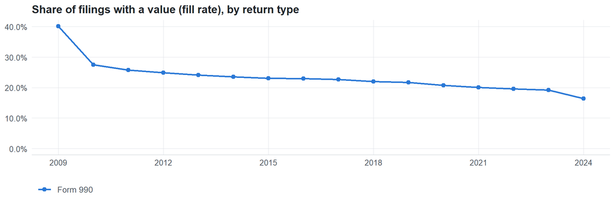

**Table view**

Table view: fill rate

| Tax year | Return type | Filings | All filings | Fill rate |
| --- | --- | --- | --- | --- |
| 2009 | Form 990 | 13,374 | 33,311 | 40.15% |
| 2010 | Form 990 | 33,775 | 123,025 | 27.45% |
| 2011 | Form 990 | 41,138 | 159,504 | 25.79% |
| 2012 | Form 990 | 44,742 | 179,688 | 24.90% |
| 2013 | Form 990 | 47,889 | 198,855 | 24.08% |
| 2014 | Form 990 | 51,450 | 218,619 | 23.53% |
| 2015 | Form 990 | 53,950 | 233,519 | 23.10% |
| 2016 | Form 990 | 55,894 | 243,903 | 22.92% |
| 2017 | Form 990 | 59,380 | 261,612 | 22.70% |
| 2018 | Form 990 | 59,727 | 271,442 | 22.00% |
| 2019 | Form 990 | 61,480 | 283,694 | 21.67% |
| 2020 | Form 990 | 66,349 | 320,342 | 20.71% |
| 2021 | Form 990 | 67,384 | 336,480 | 20.03% |
| 2022 | Form 990 | 68,248 | 349,055 | 19.55% |
| 2023 | Form 990 | 68,165 | 354,768 | 19.21% |
| 2024 | Form 990 | 45,618 | 277,298 | 16.45% |

## Repeating groups

Table cardinality in the concordance: **many**. 6 of 6 observed xpaths repeat within a filing.

Repeating element each xpath was observed in (from the raw indexed xpath)

| Xpath | Repeating element | Filings (summed over years) |
| --- | --- | --- |
| IRS990ScheduleR/Form990ScheduleRPartII/AddressForeign/ProvinceOrState | (none) | 257 |
| IRS990ScheduleR/Form990ScheduleRPartII/AddressForeign/ProvinceOrState | IRS990ScheduleR/Form990ScheduleRPartII | 460 |
| IRS990ScheduleR/Form990ScheduleRPartII/AddressUS/State | (none) | 64031 |
| IRS990ScheduleR/Form990ScheduleRPartII/AddressUS/State | IRS990ScheduleR/Form990ScheduleRPartII | 68281 |
| IRS990ScheduleR/IdRelatedTaxExemptOrgGrp/ForeignAddress/ProvinceOrState | (none) | 108 |
| IRS990ScheduleR/IdRelatedTaxExemptOrgGrp/ForeignAddress/ProvinceOrState | IRS990ScheduleR/IdRelatedTaxExemptOrgGrp | 185 |
| IRS990ScheduleR/IdRelatedTaxExemptOrgGrp/USAddress/State | (none) | 23966 |
| IRS990ScheduleR/IdRelatedTaxExemptOrgGrp/USAddress/State | IRS990ScheduleR/IdRelatedTaxExemptOrgGrp | 23630 |
| IRS990ScheduleR/IdRelatedTaxExemptOrgGrp/ForeignAddress/ProvinceOrStateNm | (none) | 2298 |
| IRS990ScheduleR/IdRelatedTaxExemptOrgGrp/ForeignAddress/ProvinceOrStateNm | IRS990ScheduleR/IdRelatedTaxExemptOrgGrp | 4057 |
| IRS990ScheduleR/IdRelatedTaxExemptOrgGrp/USAddress/StateAbbreviationCd | (none) | 336644 |
| IRS990ScheduleR/IdRelatedTaxExemptOrgGrp/USAddress/StateAbbreviationCd | IRS990ScheduleR/IdRelatedTaxExemptOrgGrp | 314646 |

## Values

| Result | Check | Detail |
| --- | --- | --- |
| ▲ warn | Small code list | up to 606 distinct values per xpath and year |
| ✓ pass | Codes share one format | 99% have the shape AA |
| ✓ pass | Consistent letter case | 0.0% of values are lower case |

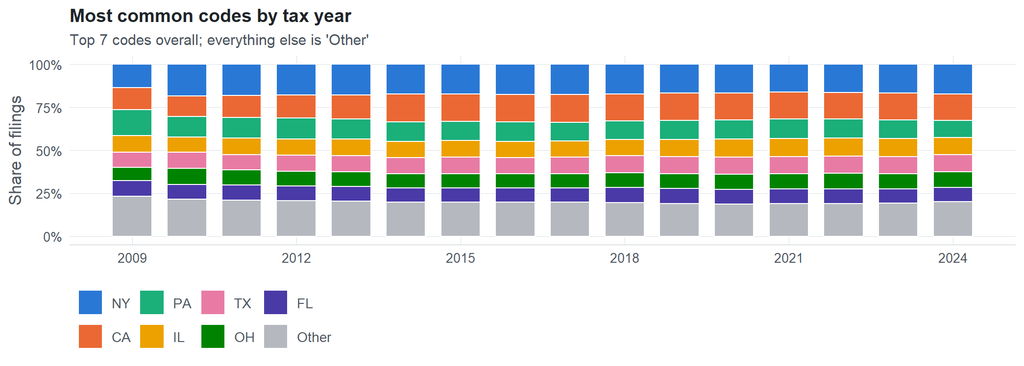

**Table view**

Table view: filings by code and tax year

| tax_year | NY | CA | PA | IL | TX | OH | FL | Other |
| --- | --- | --- | --- | --- | --- | --- | --- | --- |
| 2009 | 1,175 | 1,083 | 1,317 | 826 | 755 | 664 | 781 | 2,001 |
| 2010 | 3,900 | 2,534 | 2,547 | 1,901 | 1,958 | 2,020 | 1,806 | 4,578 |
| 2011 | 4,682 | 3,353 | 3,147 | 2,476 | 2,336 | 2,305 | 2,262 | 5,474 |
| 2012 | 5,075 | 3,757 | 3,481 | 2,655 | 2,670 | 2,394 | 2,470 | 5,831 |
| 2013 | 5,405 | 4,284 | 3,616 | 2,905 | 2,855 | 2,601 | 2,602 | 6,274 |
| 2014 | 5,693 | 5,358 | 3,763 | 3,112 | 3,115 | 2,738 | 2,718 | 6,583 |
| 2015 | 6,048 | 5,532 | 3,941 | 3,388 | 3,377 | 2,854 | 2,936 | 6,932 |
| 2016 | 6,309 | 5,765 | 4,079 | 3,388 | 3,413 | 2,972 | 2,923 | 7,211 |
| 2017 | 6,775 | 6,185 | 4,204 | 3,597 | 3,704 | 3,253 | 3,171 | 7,626 |
| 2018 | 6,979 | 6,279 | 4,273 | 3,838 | 3,913 | 3,434 | 3,621 | 7,821 |
| 2019 | 6,695 | 6,430 | 4,455 | 4,010 | 4,031 | 3,498 | 3,482 | 7,679 |
| 2020 | 7,200 | 6,721 | 4,768 | 4,516 | 4,260 | 3,826 | 3,689 | 8,071 |
| 2021 | 7,050 | 6,787 | 4,860 | 4,545 | 4,351 | 3,904 | 3,678 | 8,229 |
| 2022 | 7,171 | 6,847 | 4,858 | 4,619 | 4,396 | 3,976 | 3,724 | 8,360 |
| 2023 | 7,351 | 7,002 | 4,844 | 4,621 | 4,412 | 3,957 | 3,671 | 8,531 |
| 2024 | 4,868 | 4,322 | 2,742 | 2,835 | 2,766 | 2,610 | 2,291 | 5,646 |

Code frequencies (all xpaths, all years)

| Code | Filings | Share |
| --- | --- | --- |
| NY | 92,376 | 17.1% |
| CA | 82,239 | 15.2% |
| PA | 60,895 | 11.3% |
| IL | 53,232 | 9.8% |
| TX | 52,312 | 9.7% |
| OH | 47,006 | 8.7% |
| FL | 45,825 | 8.5% |
| MA | 36,683 | 6.8% |
| VA | 33,483 | 6.2% |
| MI | 10,539 | 1.9% |
| DC | 9,227 | 1.7% |
| NJ | 6,830 | 1.3% |
| MN | 3,385 | 0.6% |
| MO | 3,045 | 0.6% |
| ONTARIO | 1,069 | 0.2% |
| LONDON | 364 | 0.1% |
| Ontario | 306 | 0.1% |
| ENGLAND | 261 | 0.0% |
| QUEBEC | 204 | 0.0% |
| MAHARASHTRA | 204 | 0.0% |
| CANADA | 171 | 0.0% |
| MEXICO | 165 | 0.0% |
| HONDURAS | 161 | 0.0% |
| PARIS | 152 | 0.0% |
| BC | 133 | 0.0% |
| GUATEMALA | 91 | 0.0% |
| HM | 64 | 0.0% |
| SAO PAULO | 58 | 0.0% |
| RAMAT GAN | 45 | 0.0% |
| ABU DHABI | 43 | 0.0% |

First rows shown.

## Examples

| Tax year | Return | Xpath | Organization | Value | Source |
| --- | --- | --- | --- | --- | --- |
| 2024 | 990 | IRS990ScheduleR/IdRelatedTaxExemptOrgGrp/ForeignAddress/ProvinceOrStateNm | AIDS HEALTHCARE FOUNDATION | ESWATINI | [XML](https://gt990datalake-rawdata.s3.amazonaws.com/EfileData/XmlFiles/202513189349316441_public.xml) |
| 2024 | 990 | IRS990ScheduleR/IdRelatedTaxExemptOrgGrp/USAddress/StateAbbreviationCd | APPALACHIAN CENTER FOR EXCELLENCE IN | VA | [XML](https://gt990datalake-rawdata.s3.amazonaws.com/EfileData/XmlFiles/202543119349302369_public.xml) |
| 2023 | 990 | IRS990ScheduleR/IdRelatedTaxExemptOrgGrp/ForeignAddress/ProvinceOrStateNm | Harvard Real Estate - Allston Inc | MAHARASHTRA | [XML](https://gt990datalake-rawdata.s3.amazonaws.com/EfileData/XmlFiles/202541359349307959_public.xml) |
| 2023 | 990 | IRS990ScheduleR/IdRelatedTaxExemptOrgGrp/USAddress/StateAbbreviationCd | ZEPF CENTER | OH | [XML](https://gt990datalake-rawdata.s3.amazonaws.com/EfileData/XmlFiles/202423399349300887_public.xml) |
| 2022 | 990 | IRS990ScheduleR/IdRelatedTaxExemptOrgGrp/ForeignAddress/ProvinceOrStateNm | INSURANCE INFORMATION INSTITUTE INC | CENTRAL HONG KONG | [XML](https://gt990datalake-rawdata.s3.amazonaws.com/EfileData/XmlFiles/202332649349300223_public.xml) |
| 2022 | 990 | IRS990ScheduleR/IdRelatedTaxExemptOrgGrp/USAddress/StateAbbreviationCd | RIVER GARDEN GERIATRIC | FL | [XML](https://gt990datalake-rawdata.s3.amazonaws.com/EfileData/XmlFiles/202313079349302866_public.xml) |
| 2021 | 990 | IRS990ScheduleR/IdRelatedTaxExemptOrgGrp/ForeignAddress/ProvinceOrStateNm | NASEEHA USA INC | ON | [XML](https://gt990datalake-rawdata.s3.amazonaws.com/EfileData/XmlFiles/202233199349306798_public.xml) |
| 2021 | 990 | IRS990ScheduleR/IdRelatedTaxExemptOrgGrp/USAddress/StateAbbreviationCd | VIRGINIA BEACH PUBLIC SCHOOLS | VA | [XML](https://gt990datalake-rawdata.s3.amazonaws.com/EfileData/XmlFiles/202310839349300011_public.xml) |
| 2020 | 990 | IRS990ScheduleR/IdRelatedTaxExemptOrgGrp/ForeignAddress/ProvinceOrStateNm | COOPERATIVE AHORRO Y CREDITO DE AGUADILLA | Puerto Rico | [XML](https://gt990datalake-rawdata.s3.amazonaws.com/EfileData/XmlFiles/202123139349304667_public.xml) |
| 2020 | 990 | IRS990ScheduleR/IdRelatedTaxExemptOrgGrp/USAddress/StateAbbreviationCd | Managed East Chicago Housing Association Inc | IN | [XML](https://gt990datalake-rawdata.s3.amazonaws.com/EfileData/XmlFiles/202231029349301118_public.xml) |
| 2019 | 990 | IRS990ScheduleR/IdRelatedTaxExemptOrgGrp/ForeignAddress/ProvinceOrStateNm | THE KISSING WELL NFP | KAMPALA | [XML](https://gt990datalake-rawdata.s3.amazonaws.com/EfileData/XmlFiles/202033089349301003_public.xml) |
| 2019 | 990 | IRS990ScheduleR/IdRelatedTaxExemptOrgGrp/USAddress/StateAbbreviationCd | JOBE | CA | [XML](https://gt990datalake-rawdata.s3.amazonaws.com/EfileData/XmlFiles/202011139349301211_public.xml) |

## Reviewer checklist

- The definition matches the form line and instructions for every xpath’s schema years.
- Every xpath pooled here measures the same thing on the 990 and 990-EZ (close enough for analysis).
- The coverage chart has no unexplained gaps or jumps between tax years.
- Each open flag is fixed, or accepted with a note in validation_log.csv.
- Every code is valid for the list the form uses (state, country, valuation method, …).
- The code list and its meaning did not change across schema versions.
- Codes are stored as text, so values like leading zeros are preserved.

Record the review as a row in `inst/extdata/src/validation_log.csv` (variable_name, reviewer, date, status, note). Evidence built 2026-09-23 17:09:04 MST from the ef2 DuckDB builds (tax years 2009–2024).